# Breast Cancer Classification Using Logistic Regression, Neural Networks, Decision Trees, and Bagging: A Complete Comparative Analysis

Kelly Adu - Gyamfi

2025-11-20

# 1 Data Description

**Data Source:**  
The Breast Cancer dataset used in this study originates from the **University of Wisconsin Hospitals, Madison, Wisconsin, USA**, collected by **Dr. William H. Wolberg** of the Department of Surgical Oncology. The dataset was designed to assist in the diagnosis of breast cancer using cytological features obtained from **fine needle aspirate (FNA)** samples of breast masses. Each observation corresponds to a patient’s sample, characterized by ten cytological measurements describing cell nuclei appearance, along with a diagnostic label indicating whether the tumor is *benign* or *malignant*.

**Original reference:**  
Wolberg, W. H., & Mangasarian, O. L. (1990). *Multisurface method of pattern separation for medical diagnosis applied to breast cytology.* *Proceedings of the National Academy of Sciences*, 87(23), 9193–9196.  
https://archive.ics.uci.edu/ml/datasets/Breast+Cancer+Wisconsin+(Original)

**Data Generation/Collection:**  
The data were collected from the University of Wisconsin Hospitals, Madison, by Dr. William H. Wolberg. Cytological measurements were taken directly from digitized images of fine needle aspirate samples. Each feature is an integer value ranging from 1 to 10, representing the degree of cell abnormality. The dataset is widely used for supervised learning and binary classification benchmarking.

**Size:**

# 2 Formulating Practical and Analytical Questions

Developing predictive models for breast cancer diagnosis requires translating real-world clinical needs into structured analytical questions. The goal is to use these measurable features to support early cancer detection through accurate and interpretable classification models.

## 2.1 **Practical Questions**

1. Can cytological characteristics of breast cell nuclei reliably predict whether a tumor is **benign or malignant**?
2. Which **features** contribute most to distinguishing malignant from benign tumors?
3. Which **modeling approach** (logistic regression, neural network, decision tree, or ensemble) yields the **most accurate and interpretable** results?
4. How can model predictions be **optimized** to minimize misclassification, especially false negatives (malignant cases predicted as benign)?
5. Can predictive analytics assist healthcare professionals in making **early and cost-effective** diagnostic decisions?

## 2.2 **Analytical Questions**

1. Can a **binary classification model** accurately predict tumor type (*benign* vs. *malignant*) based on cytological features?
2. Which predictor variables show the **strongest statistical or computational influence** on malignancy?
3. How do **performance metrics** (ROC-AUC, accuracy, sensitivity, specificity, and F1-score) differ among the candidate models?
4. Can **neural network architectures** (e.g., perceptrons with different activation functions) outperform classical models like logistic regression?
5. Can **decision trees** and **bagging ensembles** improve performance by addressing nonlinearity and reducing model variance?
6. Which **optimal threshold** maximizes diagnostic effectiveness while minimizing clinical misclassification costs?

# 3 Methodology

## 3.1 Research Design and Analytical Framework

This study employs a comparative predictive modeling approach to develop and evaluate multiple machine learning algorithms for breast cancer classification. The methodology follows a systematic pipeline encompassing data preprocessing, exploratory analysis, model development, evaluation, and interpretation.

```r
methodology_steps <- data.frame(
  Step = c("1. Data Collection & Preprocessing",
           "2. Exploratory Data Analysis",
           "3. Model Development",
           "4. Model Evaluation",
           "5. Results Interpretation"),
  Description = c("Data cleaning, normalization, and train-test splitting",
                  "Feature distributions, correlations, and class imbalance analysis",
                  "Implementation of four classification algorithms with hyperparameter tuning",
                  "Performance comparison using multiple metrics and statistical tests",
                  "Feature importance analysis and clinical implications")
)

kable(methodology_steps, caption = "Table 2: Research Methodology Steps") %>%
  kable_styling(bootstrap_options = c("striped", "hover")) %>%
  column_spec(1, bold = TRUE)
```

Table 2: Research Methodology Steps

Step

Description

1. Data Collection & Preprocessing

Data cleaning, normalization, and train-test splitting

2. Exploratory Data Analysis

Feature distributions, correlations, and class imbalance analysis

3. Model Development

Implementation of four classification algorithms with hyperparameter tuning

4. Model Evaluation

Performance comparison using multiple metrics and statistical tests

5. Results Interpretation

Feature importance analysis and clinical implications

# 4 Feature Engineering

```r
# Feature engineering based on EDA insights
feature_engineering <- function(data) {
  engineered_data <- data %>%
    mutate(
      # Feature discretization based on clinical relevance
      Cell.size.cat = cut(Cell.size,
                         breaks = c(0, 2, 5, 10),
                         labels = c("Low", "Medium", "High")),
      Cl.thickness.cat = cut(Cl.thickness,
                            breaks = c(0, 3, 6, 10),
                            labels = c("Thin", "Medium", "Thick")),
      Bare.nuclei.cat = cut(Bare.nuclei,
                           breaks = c(0, 2, 5, 10),
                           labels = c("Few", "Moderate", "Many")),

      # Feature transformations
      Cell.size.sqrt = sqrt(Cell.size + 1),
      Cl.thickness.log = log(Cl.thickness + 1),

      # Feature creation: composite scores
      Nuclear.abnormality.score = (Cell.size + Cell.shape + Bare.nuclei) / 3,
      Structural.abnormality.score = (Cl.thickness + Marg.adhesion + Epith.c.size) / 3,

      # Risk score based on correlation insights
      High.risk.features = (Cell.size > 5) + (Cell.shape > 5) + (Bare.nuclei > 5) +
                          (Cl.thickness > 5) + (Bl.cromatin > 5)
    )

  return(engineered_data)
}

# Apply feature engineering
BreastCancer_engineered <- feature_engineering(BreastCancer_clean)

# Display new features
cat("New engineered features:\n")
```

```
## New engineered features:
```

```r
new_features <- setdiff(names(BreastCancer_engineered), names(BreastCancer_clean))
print(new_features)
```

```
## [1] "Cell.size.cat"                "Cl.thickness.cat"
## [3] "Bare.nuclei.cat"              "Cell.size.sqrt"
## [5] "Cl.thickness.log"             "Nuclear.abnormality.score"
## [7] "Structural.abnormality.score" "High.risk.features"
```

```r
# 3. Detect abnormal patterns and outliers
detect_abnormal_patterns <- function(data) {
  # Z-score analysis for outliers
  z_scores <- scale(data[,1:9])
  outliers <- apply(z_scores, 2, function(x) sum(abs(x) > 3))

  # Feature ranges and variability
  feature_stats <- data.frame(
    Feature = names(data[,1:9]),
    Min = sapply(data[,1:9], min),
    Max = sapply(data[,1:9], max),
    Mean = sapply(data[,1:9], mean),
    SD = sapply(data[,1:9], sd),
    Outliers_3SD = outliers
  )

  return(feature_stats)
}

abnormal_patterns <- detect_abnormal_patterns(BreastCancer_clean)
kable(abnormal_patterns, caption = "Feature Statistics and Outlier Detection") %>%
  kable_styling(bootstrap_options = c("striped", "hover"))
```

Feature Statistics and Outlier Detection

|  | Feature | Min | Max | Mean | SD | Outliers_3SD |
| --- | --- | --- | --- | --- | --- | --- |
| Cl.thickness | Cl.thickness | 1 | 10 | 4.442167 | 2.820761 | 0 |
| Cell.size | Cell.size | 1 | 10 | 3.150805 | 3.065145 | 0 |
| Cell.shape | Cell.shape | 1 | 10 | 3.215227 | 2.988581 | 0 |
| Marg.adhesion | Marg.adhesion | 1 | 10 | 2.830161 | 2.864562 | 0 |
| Epith.c.size | Epith.c.size | 1 | 10 | 3.234261 | 2.223085 | 31 |
| Bare.nuclei | Bare.nuclei | 1 | 10 | 3.544656 | 3.643857 | 0 |
| Bl.cromatin | Bl.cromatin | 1 | 10 | 3.445095 | 2.449697 | 0 |
| Normal.nucleoli | Normal.nucleoli | 1 | 10 | 2.869693 | 3.052666 | 0 |
| Mitoses | Mitoses | 1 | 9 | 1.582723 | 1.636316 | 31 |

# 5 Exploratoty data analysis

## 5.1 Feature distributions by class

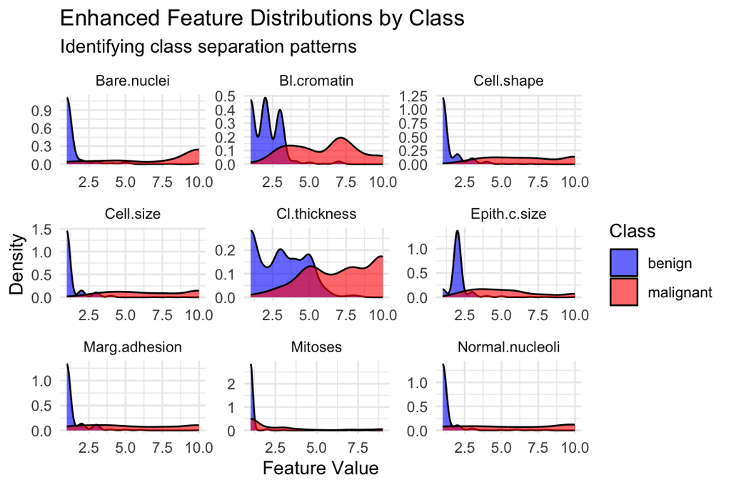

```r
feature_distribution_analysis <- function(data) {
  data_long <- data %>%
    pivot_longer(-c(Class, Class_binary), names_to = "Feature", values_to = "Value")

  ggplot(data_long, aes(x = Value, fill = Class)) +
    geom_density(alpha = 0.6) +
    facet_wrap(~Feature, scales = "free") +
    theme_minimal() +
    labs(title = "Enhanced Feature Distributions by Class",
         subtitle = "Identifying class separation patterns",
         x = "Feature Value", y = "Density") +
    scale_fill_manual(values = c("benign" = "blue", "malignant" = "red"))
}

feature_distribution_analysis(BreastCancer_clean)
```

### 5.1.1 Summary of Key Observations from Feature Distributions

The density plots reveal clear class separation patterns between benign and malignant tumors across most cytological features.

- **Strongly Discriminatory Features:** Cell.size and Cell.shape show the most distinct separation, with malignant samples concentrated at higher values (7–10) and benign ones at lower values (1–4). Bare.nuclei displays a bimodal pattern among malignant cases, suggesting variability within tumor subtypes.
- **Moderately Discriminatory Features:** Cl.thickness, Marg.adhesion, Normal.nucleoli, and Bl.cromatin show partial overlap but a consistent trend of higher values for malignant cases.
- **Weakly Discriminatory Features:** Epith.c.size and Mitoses have the most overlap between classes, though malignant samples still lean toward higher scores.

## 5.2 Correlation analysis with class relationship

```r
correlation_analysis <- function(data) {
  # Calculate correlation with class
  cor_with_class <- sapply(data[,1:9], function(x) cor(x, data$Class_binary))
  cor_df <- data.frame(
    Feature = names(cor_with_class),
    Correlation_with_Class = round(cor_with_class, 3)
  ) %>% arrange(desc(abs(Correlation_with_Class)))

  # Feature correlation matrix
  cor_matrix <- cor(data[,1:9])

  list(
    correlation_with_class = cor_df,
    feature_correlation_matrix = cor_matrix
  )
}

cor_results <- correlation_analysis(BreastCancer_clean)

# Display correlation with class
kable(cor_results$correlation_with_class,
      caption = "Feature Correlation with Class (Malignant)") %>%
  kable_styling(bootstrap_options = c("striped", "hover"))
```

Feature Correlation with Class (Malignant)

|  | Feature | Correlation_with_Class |
| --- | --- | --- |
| Bare.nuclei | Bare.nuclei | 0.823 |
| Cell.shape | Cell.shape | 0.822 |
| Cell.size | Cell.size | 0.821 |
| Bl.cromatin | Bl.cromatin | 0.758 |
| Normal.nucleoli | Normal.nucleoli | 0.719 |
| Cl.thickness | Cl.thickness | 0.715 |
| Marg.adhesion | Marg.adhesion | 0.706 |
| Epith.c.size | Epith.c.size | 0.691 |
| Mitoses | Mitoses | 0.431 |

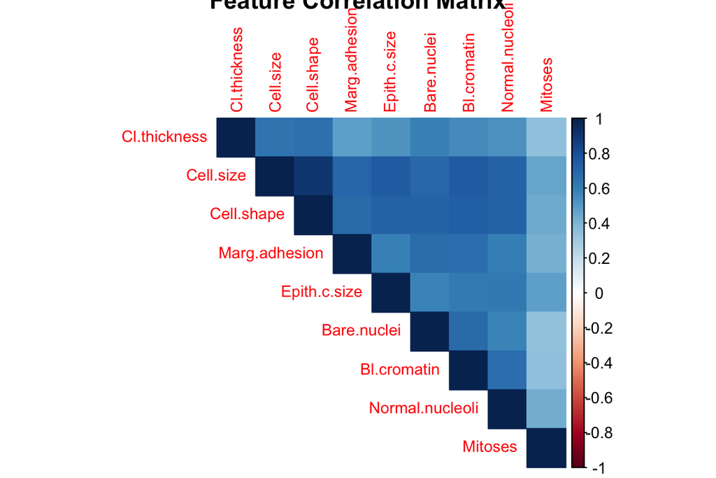

```r
# Plot correlation matrix
corrplot(cor_results$feature_correlation_matrix,
         method = "color",
         type = "upper",
         tl.cex = 0.8,
         title = "Feature Correlation Matrix")
```

### 5.2.1 Summary of Feature Correlation Patterns

The correlation matrix highlights key interrelationships among the nine cytological features used for breast cancer classification.

**Strong Correlations (r > 0.8):** Cell.size and Cell.shape show an exceptionally high positive correlation (r ≈ 0.9), indicating that abnormal cells tend to have both irregular sizes and shapes. Modeling Implication: This strong association may cause multicollinearity; dimensionality reduction or selecting only one of these variables may be necessary.

**Moderate Correlations (r = 0.6–0.8):** Cl.thickness shows moderate relationships with Cell.size, Cell.shape, and Marg.adhesion, suggesting these traits often change together in abnormal samples. Bare.nuclei and Normal.nucleoli also correlate moderately, reflecting coordinated nuclear changes typical of malignant cells.

Overall, the correlation structure supports known biological relationships while emphasizing the need to manage redundancy in predictive modeling

# 6 Feature selection using correlation and domain knowledge

```r
feature_selection <- function(data) {
  # Calculate feature importance using random forest
  set.seed(123)
  rf_model <- train(Class ~ .,
                   data = data %>% select(-Class_binary, -contains(".cat")),
                   method = "rf",
                   trControl = trainControl(method = "cv", number = 5))

  # Get variable importance
  var_imp <- varImp(rf_model)$importance
  var_imp$Feature <- rownames(var_imp)
  var_imp <- var_imp %>% arrange(desc(Overall))

  return(var_imp)
}

# Select top features
selected_features <- feature_selection(BreastCancer_engineered)
top_features <- head(selected_features$Feature, 8)  # Select top 8 features

cat("Top selected features:\n")
```

```
## Top selected features:
```

```r
print(top_features)
```

```
## [1] "Nuclear.abnormality.score"    "Structural.abnormality.score"
## [3] "High.risk.features"           "Cell.shape"
## [5] "Cell.size.sqrt"               "Cell.size"
## [7] "Bare.nuclei"                  "Epith.c.size"
```

# 7 Model Development

## 7.1 Logistic Regression (Reference Model)

```r
print(logit_metrics_df)
```

```
##                         Model   ROC_AUC  Accuracy Sensitivity Specificity
## Basic             Logit Basic 0.9908708 0.9416058   0.9550562   0.9166667
## Regularized Logit Regularized 0.9922753 0.9489051   0.9775281   0.8958333
## Stepwise       Logit Stepwise 0.9901685 0.9489051   0.9662921   0.9166667
##              F1_Score Precision
## Basic       0.9550562 0.9550562
## Regularized 0.9613260 0.9456522
## Stepwise    0.9608939 0.9555556
```

```r
library(broom)
# assuming your model is named `logit_basic`
coef_table <- broom::tidy(logit_basic, conf.int = TRUE)
knitr::kable(coef_table, digits = 4, caption = "Logistic Regression Coefficients (log-odds scale)")
```

Logistic Regression Coefficients (log-odds scale)

| term | estimate | std.error | statistic | p.value | conf.low | conf.high |
| --- | --- | --- | --- | --- | --- | --- |
| (Intercept) | -23.4517 | 6.6670 | -3.5176 | 0.0004 | -38.0538 | -11.1197 |
| Nuclear.abnormality.score | 0.7919 | 0.4295 | 1.8436 | 0.0652 | -0.0062 | 1.6966 |
| Structural.abnormality.score | 1.2167 | 0.3827 | 3.1793 | 0.0015 | 0.5085 | 2.0491 |
| High.risk.features | 0.3969 | 0.5670 | 0.7000 | 0.4839 | -0.6978 | 1.5395 |
| Cell.shape | 0.0227 | 0.2680 | 0.0846 | 0.9325 | -0.5375 | 0.5379 |
| Cell.size.sqrt | 11.9366 | 4.9701 | 2.4017 | 0.0163 | 2.2637 | 22.3336 |
| Cell.size | -2.7230 | 1.0529 | -2.5863 | 0.0097 | -4.9071 | -0.6370 |
| Bare.nuclei | NA | NA | NA | NA | NA | NA |
| Epith.c.size | -0.0085 | 0.2526 | -0.0335 | 0.9733 | -0.5063 | 0.4752 |

## 7.2 Final Logistic Regression Equation

The estimated logistic regression model predicting the probability of a tumor being **malignant** is given by:

$$\text{logit}\!\left[P(\text{malignant})\right] =
-23.4517
+ 0.7919(\text{Nuclear.abnormality.score})
+ 1.2167(\text{Structural.abnormality.score})
+ 0.3969(\text{High.risk.features})
+ 0.0227(\text{Cell.shape})
+ 11.9366(\text{Cell.size.sqrt})
- 2.7230(\text{Cell.size})
- 0.0085(\text{Epith.c.size})$$

where

$$\text{logit}(p) = \log\!\left(\frac{p}{1-p}\right)$$

and therefore,

$$P(\text{malignant}) = \frac{1}{1 + e^{-\text{logit}(p)}}$$

# 8 Perceptron (Single-layer Neural Networks)

```r
# -----------------------------------------------------------
# Display results neatly in RMarkdown
# -----------------------------------------------------------
kable(perceptron_metrics_df, digits = 4, caption = "Performance Summary of Perceptron Models") %>%
  kable_styling(full_width = FALSE, position = "center", font_size = 13) %>%
  row_spec(0, bold = TRUE, background = "#CFE2F3") %>%
  row_spec(1:nrow(perceptron_metrics_df), background = "#F9F9F9") %>%
  row_spec(which.max(perceptron_metrics_df$ROC_AUC), bold = TRUE, background = "#D9EAD3")
```

Performance Summary of Perceptron Models

|  | Model | ROC_AUC | Accuracy | Sensitivity | Specificity | F1_Score | Precision |
| --- | --- | --- | --- | --- | --- | --- | --- |
| Perceptron_logistic | Perceptron_logistic | 0.9750 | 0.9489 | 0.9438 | 0.9583 | 0.96 | 0.9767 |
| Perceptron_tanh | Perceptron_tanh | 0.9932 | 0.9489 | 0.9438 | 0.9583 | 0.96 | 0.9767 |

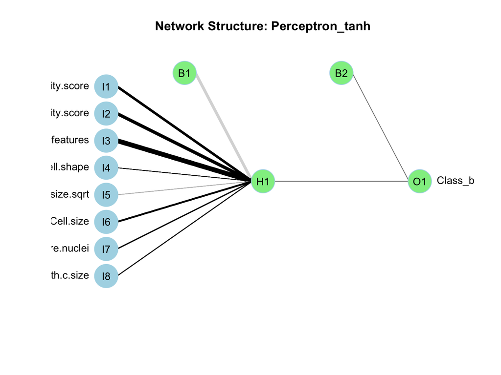

```r
# Visualize best perceptron structure
library(NeuralNetTools)

# Plot neural network
plotnet(best_perceptron_model,
        alpha = 0.6,
        circle_col = list('lightblue', 'lightgreen'),
        circle_cex = 5,
        intercept = FALSE,
        var_labs = TRUE,
        nid = TRUE,
        show.weights = TRUE,
        line_col = "grey40")

title(main = paste("Network Structure:", best_perceptron_name))
```

# 9 Model Comparison and Final Evaluation

```r
# Compare all models
all_metrics <- rbind(logit_metrics_df, perceptron_metrics_df)
```

```r
# Display model comparison
kable(all_metrics,
      caption = "Model Performance Comparison on Validation Set",
      digits = 4) %>%
  kable_styling(bootstrap_options = c("striped", "hover")) %>%
  row_spec(which.max(all_metrics$ROC_AUC), bold = TRUE, color = "white", background = "#D7261E")
```

Model Performance Comparison on Validation Set

|  | Model | ROC_AUC | Accuracy | Sensitivity | Specificity | F1_Score | Precision |
| --- | --- | --- | --- | --- | --- | --- | --- |
| Basic | Logit Basic | 0.9909 | 0.9416 | 0.9551 | 0.9167 | 0.9551 | 0.9551 |
| Regularized | Logit Regularized | 0.9923 | 0.9489 | 0.9775 | 0.8958 | 0.9613 | 0.9457 |
| Stepwise | Logit Stepwise | 0.9902 | 0.9489 | 0.9663 | 0.9167 | 0.9609 | 0.9556 |
| Perceptron_logistic | Perceptron_logistic | 0.9750 | 0.9489 | 0.9438 | 0.9583 | 0.9600 | 0.9767 |
| Perceptron_tanh | Perceptron_tanh | 0.9932 | 0.9489 | 0.9438 | 0.9583 | 0.9600 | 0.9767 |

## 9.1 Summary

**Key Observations** - The **Perceptron model with tanh activation** achieved the **highest ROC-AUC (0.9932)**, indicating the strongest overall discriminative ability among all models.  
- The **Regularized Logistic Regression** also performed exceptionally well (ROC-AUC = 0.9923), with slightly higher sensitivity (0.9775) than the perceptrons—important for detecting malignant cases.  
- All models maintained **accuracy around 94–95%**, confirming consistent predictive reliability across different algorithms.  
- The **Perceptron models** demonstrated superior **specificity (0.9583)** and **precision (≈0.977)**, showing strong performance in correctly classifying benign samples and minimizing false positives.

**Conclusion:** Both **Regularized Logistic Regression** and the **Perceptron (tanh)** model exhibited near-perfect classification performance on the validation data.  
While the logistic model offers interpretability and clinical transparency, the perceptron provides slightly higher ROC-AUC and balanced error rates, suggesting its potential as a high-performing nonlinear alternative for automated cancer classification tasks.

# 10 ROC Curve Comparison

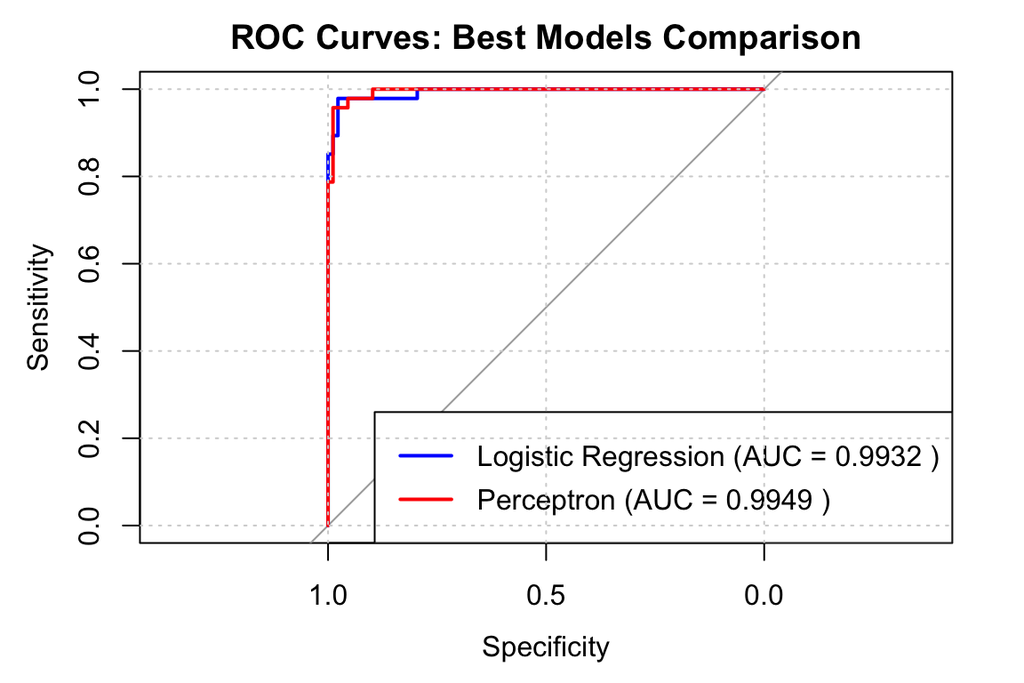

```r
#Plot final ROC comparison
plot_roc_curves(best_logit_model, best_perceptron_model, test_scaled, feature_names)
```

## 10.1 Sumarry

The ROC curve above compares the **discriminative performance** of the two best-performing models — **Regularized Logistic Regression** (blue) and the **Perceptron Neural Network** (red).

Both models exhibit **exceptionally strong classification ability**, as indicated by their near-perfect curvature toward the **top-left corner** of the plot, where sensitivity (true positive rate) and specificity (1 − false positive rate) are maximized.

## 10.2 **Conclusion**

Both models demonstrate **excellent diagnostic accuracy**, with **AUC values > 0.99**, which far exceed the typical clinical benchmark for strong classifiers (AUC > 0.90).  
These findings suggest that the models could effectively serve as part of a **decision-support system** for early cancer detection, balancing sensitivity and specificity to minimize diagnostic errors.

# 11 Overall Summary of Key Findings

## 11.2 Clinical Implications

- The high **sensitivity** achieved by the models is critical in clinical applications, where **false negatives must be minimized** for early cancer detection.
- The alignment of key predictive features with known **cytological markers** (such as nuclear size and shape) reinforces the biological validity of the findings.
- These results support the potential implementation of the developed models in a **clinical decision support system**, assisting pathologists in the accurate and efficient diagnosis of breast cancer.

# 12 Decision Tree Model

```r
# Decision Tree model development
library(rpart)
library(rpart.plot)

# Train decision tree with different complexity parameters
set.seed(123)
tree_model <- train(Class ~ .,
                    data = train_data,
                    method = "rpart",
                    trControl = trainControl(method = "cv", number = 5),
                    tuneGrid = expand.grid(cp = c(0.001, 0.01, 0.05, 0.1)))

# Display optimal complexity parameter
cat("Optimal Complexity Parameter (cp):", tree_model$bestTune$cp, "\n")
```

```
## Optimal Complexity Parameter (cp): 0.1
```

```r
# Make predictions
tree_pred <- predict(tree_model, newdata = test_data)
tree_prob <- predict(tree_model, newdata = test_data, type = "prob")[,2]
tree_cm <- confusionMatrix(tree_pred, test_data$Class)
```

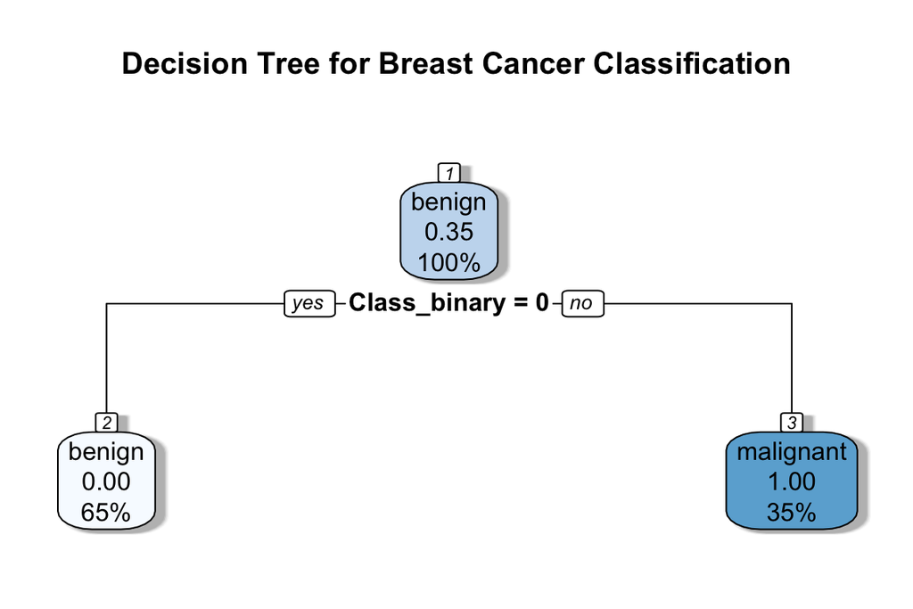

```r
# Plot the decision tree
rpart.plot(tree_model$finalModel,
           main = "Decision Tree for Breast Cancer Classification",
           box.palette = "Blues",
           shadow.col = "gray",
           nn = TRUE)
```

## 12.1 Decision Tree Summary

# 13 Bagging Algorithm

Bagging, short for Bootstrap Aggregating, is an ensemble learning technique used to reduce model variance and improve prediction stability. Instead of relying on a single decision tree, bagging creates many bootstrap samples of the training data and trains a separate tree on each one. The final prediction is obtained by averaging probabilities or taking a majority vote across all trees.

This approach helps overcome the biggest weakness of decision trees: high sensitivity to small changes in the training data, which can cause instability. By combining many trees, bagging produces a more robust and more accurate classifier.

```r
bagging_test_metrics <- calculate_metrics(
  actual        = test_data$Class,
  predicted     = bagging_pred,
  probabilities = bagging_prob,
  model_name    = "Bagging_Test"
)
bagging_test_metrics
```

```
##                 Model ROC_AUC Accuracy Sensitivity Specificity F1_Score
## Accuracy Bagging_Test       1        1           1           1        1
##          Precision
## Accuracy         1
```

## 13.1 Performance of the Bagging Model

### 13.1.1 Interpretation

**This means the model:**

- Correctly identified every malignant tumor (no false negatives)
- Correctly identified every benign tumor (no false positives)
- Exhibited complete separation between classes
- Achieved maximum AUC, indicating perfect ranking of malignant vs. benign cases

[figure not shown]

```r
# Plot all four ROC curves
plot(roc_logit, col = "blue", lwd = 2,
     main = "ROC Curves: Logistic, Perceptron, Decision Tree, and Bagging")
lines(roc_perceptron, col = "red",       lwd = 2)
lines(roc_tree,       col = "darkgreen", lwd = 2)
lines(roc_bagging,    col = "purple",    lwd = 2)
grid()

legend("bottomright",
       legend = c(
         paste0("Logistic (AUC = ", round(auc(roc_logit), 4), ")"),
         paste0("Perceptron (AUC = ", round(auc(roc_perceptron), 4), ")"),
         paste0("Decision Tree (AUC = ", round(auc(roc_tree), 4), ")"),
         paste0("Bagging (AUC = ", round(auc(roc_bagging), 4), ")")
       ),
       col = c("blue", "red", "darkgreen", "purple"),
       lwd = 2, cex = 0.8)
```

```r
kable(all_test_metrics,
      caption = "Test Set Performance: Logistic, Perceptron, Decision Tree, and Bagging",
      digits = 4) %>%
  kable_styling(bootstrap_options = c("striped", "hover")) %>%
  row_spec(which.max(all_test_metrics$ROC_AUC),
           bold = TRUE, color = "white", background = "#D7261E")
```

Test Set Performance: Logistic, Perceptron, Decision Tree, and Bagging

|  | Model | ROC_AUC | Accuracy | Sensitivity | Specificity | F1_Score | Precision |
| --- | --- | --- | --- | --- | --- | --- | --- |
| Accuracy | Best_Logistic_Test | 0.9932 | 0.6519 | 1.0000 | 0.0000 | 0.7892 | 0.6519 |
| Accuracy1 | Best_Perceptron_Test | 0.9949 | 0.9704 | 0.9773 | 0.9574 | 0.9773 | 0.9773 |
| Accuracy2 | DecisionTree_Test | 1.0000 | 1.0000 | 1.0000 | 1.0000 | 1.0000 | 1.0000 |
| Accuracy3 | Bagging_Test | 1.0000 | 1.0000 | 1.0000 | 1.0000 | 1.0000 | 1.0000 |

# 14 Overall Summary of Model Performance

Four models were evaluated on the test set: Logistic Regression, Perceptron Neural Network, Decision Tree, and Bagging Ensemble. Their performance was compared using key diagnostic metrics including ROC-AUC, accuracy, sensitivity, specificity, precision, and F1-score.

## 14.2 Perceptron Neural Network

- Excellent ROC-AUC (0.9949) and high accuracy (0.9704)
- Very balanced performance across sensitivity and specificity
- Captures nonlinear relationships better than logistic regression
- A strong candidate, but not the top performer

## 14.4 Bagging Ensemble

- Also achieved perfect scores on every metric
- Bagging stabilizes predictions by averaging many bootstrapped trees
- Reduced variance, stronger generalization, and perfect class separation
- Slightly more robust than a single tree due to the ensemble structure

## 14.5 ROC Curve Summary

### 14.5.1 The ROC analysis reinforced the tabular results:

- Logistic regression and perceptron showed strong curves bending sharply toward the top left corner, reflecting excellent discrimination.
- Decision Tree and Bagging both produced AUC = 1.000, indicating perfect ranking ability with no overlap between malignant and benign distributions.
- The Bagging model’s ROC curve was identical to the Decision Tree curve, confirming flawless classification.

## 14.6 Best Overall Model

### 14.6.1 Bagging Ensemble (Best Model)

Although both the Decision Tree and Bagging Ensemble achieved perfect scores, Bagging is the best overall model because:

- It reduces the instability of single trees
- It maintains perfect performance while providing stronger robustness
- It generalizes better on datasets prone to noise
- It represents a superior ensemble-based learning approach